# EAS 509 Project 2

jayyoges

2023-11-27

# Project 2

## Importing the data

```r
data = read.csv('oil.csv')
head(data)
```

```
##         date dcoilwtico
## 1 2013-01-01         NA
## 2 2013-01-02      93.14
## 3 2013-01-03      92.97
## 4 2013-01-04      93.12
## 5 2013-01-07      93.20
## 6 2013-01-08      93.21
```

```r
str(data)
```

```
## 'data.frame':    1218 obs. of  2 variables:
##  $ date      : chr  "2013-01-01" "2013-01-02" "2013-01-03" "2013-01-04" ...
##  $ dcoilwtico: num  NA 93.1 93 93.1 93.2 ...
```

```r
data <- data %>% setNames(c('Date', 'Price'))
data$Date <- as.Date(data$Date)
```

# Phase 1: EDA & Data Cleaning

## Checking for missing values in the data

```r
# How many missing values?
missing_values <- sum(is.na(data))

# Print the number of missing values
cat("Number of missing values in the entire data frame:", missing_values, "\n")
```

```
## Number of missing values in the entire data frame: 43
```

```r
# Check for missing values in each column
missing_values_per_column <- sapply(data, function(x) sum(is.na(x)))

# Print the number of missing values for each column
cat("Number of missing values per column:\n")
```

```
## Number of missing values per column:
```

```r
print(missing_values_per_column)
```

```
##  Date Price
##     0    43
```

We have 43 missing values for oil price

```r
# Identify rows with missing values in a specific column
rows_with_missing_values <- which(is.na(data$Price))

# Print the rows with missing values
cat("Rows with missing values in column 'Price':\n")
```

```
## Rows with missing values in column 'Price':
```

```r
print(rows_with_missing_values)
```

```
##  [1]    1   15   35   64  105  133  175  238  257  262  275  295  339  365  394
## [16]  435  498  518  523  535  555  589  625  654  700  758  779  784  795  815
## [31]  844  890  915  960 1018 1040 1045 1055 1080 1119 1150 1175 1176
```

## Plot before imputing

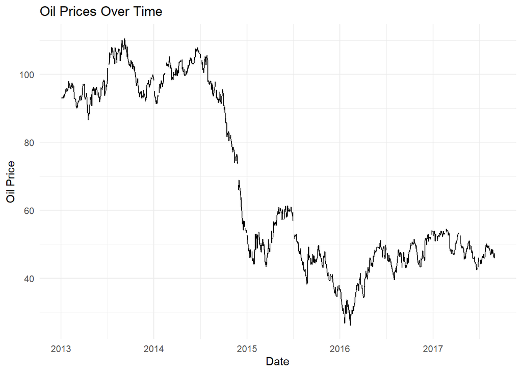

```r
oilplot = function(data, title = "Oil Prices Over Time") {
  ggplot(data, aes(x = Date, y = Price)) +
    geom_line() +
    labs(title = title,
        x = "Date",
        y = "Oil Price") +
    theme_minimal()
}

oilplot(data)
```

## Imputing the data

```r
# Forward Fill
data_ffill <- data
data_ffill$Price <- na.locf(data_ffill$Price, na.rm = FALSE)

# Backward Fill
data_bfill <- data
data_bfill$Price <- na.locf(data_bfill$Price, fromLast = TRUE)

# Linear Interpolation
data_linear <- data
data_linear$Price <- na.approx(data_linear$Price, na.rm = FALSE)

# Moving Average
k <- 5
data_ma <- data
data_ma$Price <- na.fill(data_ma$Price, fill = "extend")
data_ma$Price <- rollapply(data_ma$Price, k, FUN = mean, na.rm = TRUE, fill = NA, align = 'center')
```

## Missing values after imputation

```r
cat("Missing values in Original data:", sum(is.na(comparison_df$Original)))
```

```
## Missing values in Original data: 43
```

```r
cat("Missing values after Forward Fill Imputation:", sum(is.na(comparison_df$ForwardFill)))
```

```
## Missing values after Forward Fill Imputation: 1
```

```r
cat("Missing values after Backward Fill Imputation:", sum(is.na(comparison_df$BackwardFill)))
```

```
## Missing values after Backward Fill Imputation: 0
```

```r
cat("Missing values after Linear Interpolation Imputation:", sum(is.na(comparison_df$LinearInterpolation)))
```

```
## Missing values after Linear Interpolation Imputation: 1
```

```r
cat("Missing values after Moving Average Imputation:", sum(is.na(comparison_df$MovingAverage)))
```

```
## Missing values after Moving Average Imputation: 4
```

## Data Plots After Imputation

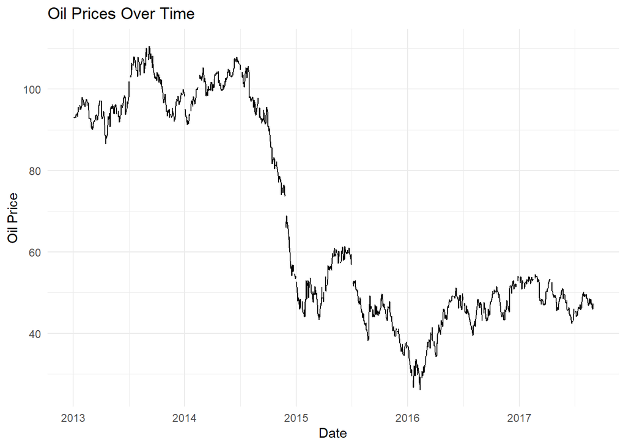

```r
oilplot(data)
```

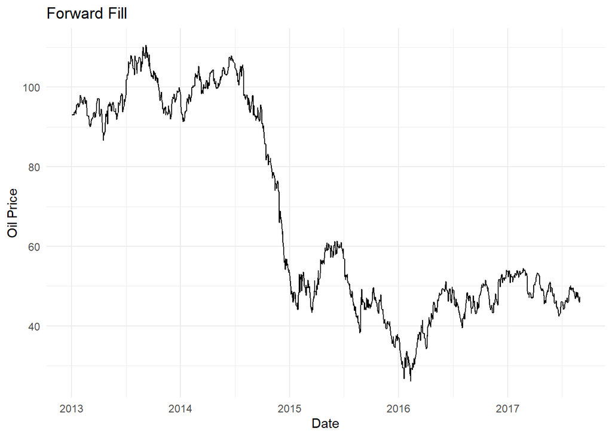

```r
oilplot(data_ffill, "Forward Fill")
```

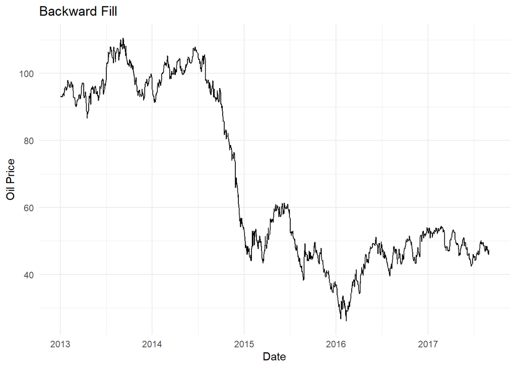

```r
oilplot(data_bfill, "Backward Fill")
```

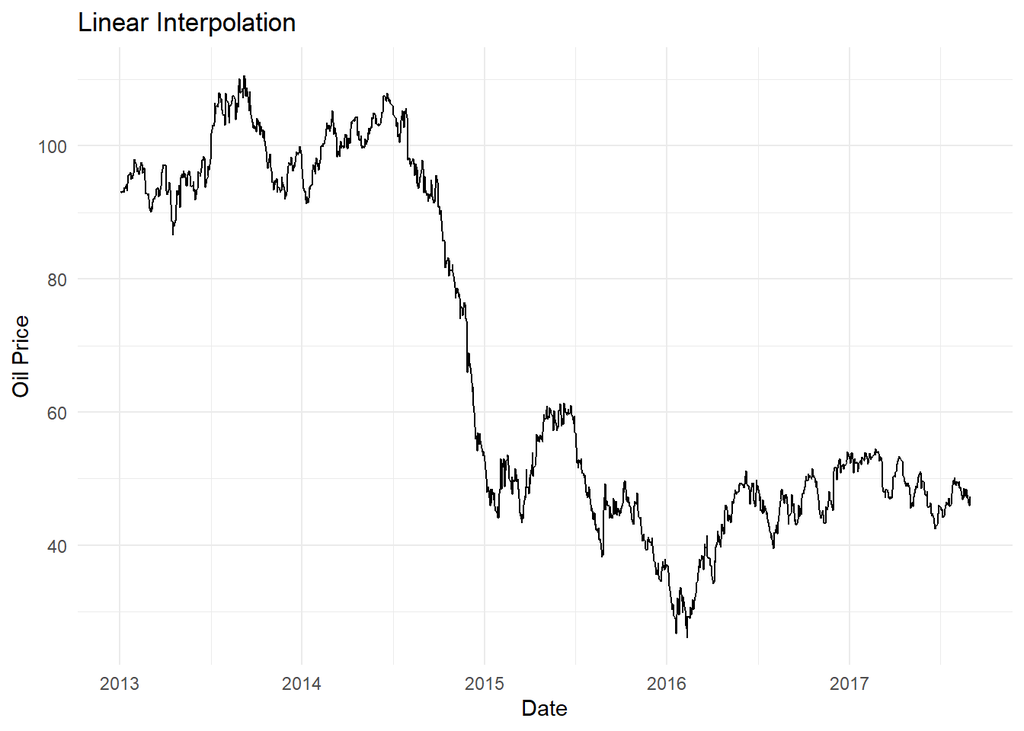

```r
oilplot(data_linear, "Linear Interpolation")
```

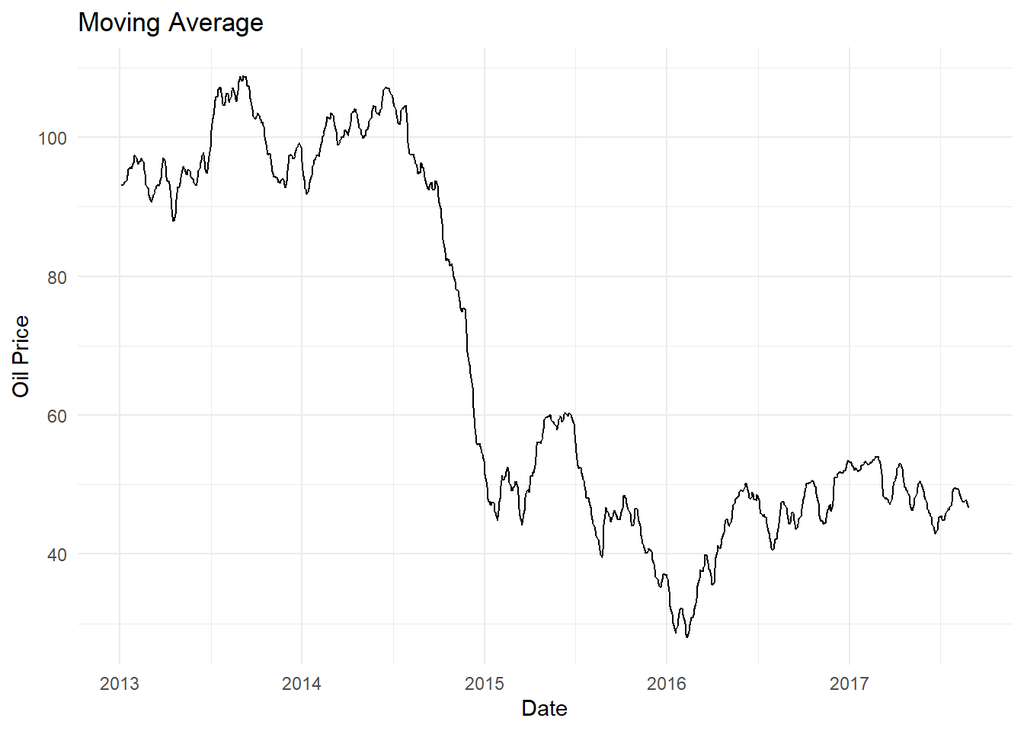

```r
oilplot(data_ma, "Moving Average")
```

#### All imputation methods except backward fill are unable to fill in all missing values, thus we pick backward fill imputed data.

# Now Checking for seasonality in the time series data

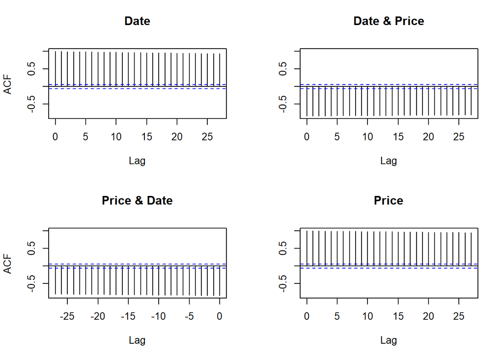

```r
# ACF plot
acf(data_bfill)
```

Here all the bars for our ACF plots are of same height. We can not see any spike in the graph for any lags which suggest that there is no strong seasonality in the data.

# Phase 2: Models considered for Training & Evaluation

## Models Overview

### 1. Simple Exponential Smoothing (ETS Model: ANN)

**Theory:** Simple Exponential Smoothing (SES) is used for forecasting univariate time series data. This method is particularly useful when the data do not show any clear trend or seasonal pattern.

In this model, forecasts are calculated using weighted averages of past observations, where the weights decrease exponentially as observations get older, hence the name “exponential smoothing.”

**Model Characteristics:** ANN (Additive error, No trend, No seasonality): This is is the most basic version of the ETS model and is appropriate for time series data that lacks an identifiable trend or seasonal pattern. It smooths out random fluctuations in the data, making it suitable for short-term forecasting.

In the additive error model, the forecast errors are assumed to be randomly distributed around zero.

### 2. ETS Model with Additive Error and Trend (AAN)

**Theory:** This model introduces a trend component to the basic exponential smoothing method, making it more suitable for data that shows a linear trend over time.

**Model Characteristics:** AAN (Additive error, Additive trend, No seasonality): It’s designed for time series data where the trend is linear and the magnitude of the trend is consistent over time. The additive trend implies that the magnitude of the trend is constant over time.

The additive nature of the trend suggests that it adds a constant value in each successive period.

### 3. Auto ARIMA Model

**Theory:** The ARIMA model is a generalization of an autoregressive moving average (ARMA) model. It’s particularly useful for data that exhibit non-stationarity, which is common in economic time series. They incorporate the differencing of raw observations (i.e., subtracting an observation from an observation at the previous time step) to make the time series stationary.

**Model Characteristics:** Components: The model is characterized by three parameters: p (AR terms), d (differencing order), and q (MA terms).

Auto ARIMA automates the process of selecting the best combination of these parameters to fit the time series data optimally.

### 4. Simple Exponential Smoothing (ZNN)

**Theory:** This approach involves an automated selection of the most appropriate ETS model based on the data. It adapts to various types of time series data without the need for manual specification of the model’s components.

**Model Characteristics:** Automatic Model Selection: The algorithm assesses various combinations of error, trend, and seasonality and chooses the one that best fits the data.

This method is particularly useful when there is uncertainty about the specific nature of the time series data.

### 5. Damped Trend Exponential Smoothing

**Theory:** This model is an extension of the ETS model that includes a damped trend component. It is particularly useful for long-term forecasting where trends are expected to diminish over time.

**Model Characteristics:** Damped Trend: Unlike a simple linear trend, a damped trend slows down over time, becoming flatter in the future. This feature makes the model less aggressive in projecting future values, often leading to more realistic and conservative long-term forecasts.

This model is best suited for time series data where the trend is expected to lose momentum over time.

## Implementation

R script is designed for time series analysis, specifically for modeling and evaluating oil prices. It follows these steps:

**Model Training:** Various time series forecasting models are trained using the Price column from the data dataset. The models include: - Simple Exponential Smoothing (ETS ANN model) - ETS with Additive Error and Trend (AAN model) - Auto ARIMA Model - Simple Exponential Smoothing (ZNN model) - Damped Trend Exponential Smoothing (AAN model with damping)

**Model Evaluation (Optional):** If the eval parameter is TRUE, the data_evaluation function is called to evaluate these models. This function prints summaries and accuracy metrics for each model.

```r
data_models <- function(data, eval = TRUE) {
  # 1. Simple Exponential Smoothing (ETS Model: ANN)
  ets_model1 <- ets(data$Price, model="ANN")

  #2. ETS Model with Additive Error and Trend (AAN)
  ets_model2 <- ets(data$Price, model="AAN")

  #3. Auto ARIMA Model
  best_arima_model <- auto.arima(data$Price)

  #4. Simple Exponential Smoothing
  ses_model <- ets(data$Price, model="ZNN")

  #5. Damped Trend Exponential Smoothing
  dtes_model <- ets(data$Price, model="AAN", damped=TRUE)


  autoplot(ets_model1) + xlab("Time") + ylab("Oil Prices") + ggtitle("ETS Model Fit")
  autoplot(ets_model2) + xlab("Time") + ylab("Oil Prices") + ggtitle("ETS Model Fit")
  autoplot(best_arima_model) + xlab("Time") + ylab("Oil Prices") + ggtitle("Auto ARIMA Model Fit")
  autoplot(ses_model) + xlab("Time") + ylab("Oil Prices") + ggtitle("Simple Exponential Smoothing")
  autoplot(dtes_model) + xlab("Time") + ylab("Oil Prices") + ggtitle("Damped Trend Exponential Smoothing")

  if (eval) {
    data_evaluation(ets_model1, ets_model2, best_arima_model, ses_model, dtes_model)
  }
}

data_evaluation <- function(ets_model1, ets_model2, best_arima_model, ses_model, dtes_model) {
  cat("---- ETS Model 1 (ANN) ----\n")
  print(summary(ets_model1))
  print(accuracy(ets_model1))
  cat("\n--------------------------------\n")

  cat("---- ETS Model 2 (AAN) ----\n")
  print(summary(ets_model2))
  print(accuracy(ets_model2))
  cat("\n--------------------------------\n")

  cat("---- Auto ARIMA Model  ----\n")
  print(summary(best_arima_model))
  print(accuracy(best_arima_model))
  cat("\n--------------------------------\n")

  cat("---- Simple Exponential Smoothing ----\n")
  print(summary(ses_model))
  print(accuracy(ses_model))
  cat("\n--------------------------------\n")

  cat("---- Damped Trend Exponential Smoothing̥ ----\n")
  print(summary(dtes_model))
  print(accuracy(dtes_model))
  cat("\n--------------------------------\n")
}
```

```r
data_models(data_bfill)
```

```
## ---- ETS Model 1 (ANN) ----
## ETS(A,N,N)
##
## Call:
##  ets(y = data$Price, model = "ANN")
##
##   Smoothing parameters:
##     alpha = 0.954
##
##   Initial states:
##     l = 93.1356
##
##   sigma:  1.2028
##
##      AIC     AICc      BIC
## 9107.716 9107.735 9123.031
##
## Training set error measures:
##                       ME    RMSE       MAE         MPE     MAPE     MASE
## Training set -0.03953028 1.20184 0.8965985 -0.08424058 1.551493 1.001156
##                       ACF1
## Training set -0.0008160611
##                       ME    RMSE       MAE         MPE     MAPE     MASE
## Training set -0.03953028 1.20184 0.8965985 -0.08424058 1.551493 1.001156
##                       ACF1
## Training set -0.0008160611
##
## --------------------------------
## ---- ETS Model 2 (AAN) ----
## ETS(A,A,N)
##
## Call:
##  ets(y = data$Price, model = "AAN")
##
##   Smoothing parameters:
##     alpha = 0.9436
##     beta  = 1e-04
##
##   Initial states:
##     l = 92.6614
```

[output cut: 80 more lines]

```
##
##      AIC     AICc      BIC
## 9111.022 9111.092 9141.652
##
## Training set error measures:
##                       ME     RMSE       MAE         MPE     MAPE     MASE
## Training set -0.02997243 1.200512 0.8958208 -0.06055127 1.548592 1.000288
##                      ACF1
## Training set 0.0006586526
##                       ME     RMSE       MAE         MPE     MAPE     MASE
## Training set -0.02997243 1.200512 0.8958208 -0.06055127 1.548592 1.000288
##                      ACF1
## Training set 0.0006586526
##
## --------------------------------
```

## Model Performance Evaluation

In our analysis, we evaluated several models to forecast oil prices, using key statistical metrics to assess their performance. These metrics include Mean Error (ME), Root Mean Square Error (RMSE), Mean Absolute Error (MAE), Mean Percentage Error (MPE), Mean Absolute Percentage Error (MAPE), Mean Absolute Scaled Error (MASE), and the Autocorrelation of the first lag (ACF1). Each metric provides a different perspective on the accuracy and reliability of the forecasting models.

### Specific details of the **Auto ARIMA Model** are as follows:

- Model Type: ARIMA(0,1,0)
- $sigma^2$ = 1.449
- Log Likelihood = -1952.37
- AIC = 3906.73
- AICc = 3906.73
- BIC = 3911.83

This information indicates a simple model without AR or MA components but with a differencing order of 1, suggesting that the model primarily focuses on capturing the changes rather than absolute levels in the oil price series.